# Estimation of Miami University Commuter Emissions

Ryan McCollum and Hannah Schultz

2024-10-23

## I. Introduction

As a growing public university, Miami University has a commitment to sustainability. Miami’s Climate Action Plan promises carbon neutrality for the Oxford campus by 2040, 10 years prior to other Ohio public universities (Miami 2040: Miami University’s Climate Action Plan, 2024). To implement steps in reducing Miami’s carbon footprint, a voluntary commuter-only survey was added to Oxford campus parking pass application forms for the fiscal year (FY) 2023. Both faculty and student applicants provided data regarding their commute to the university in order to estimate commuting mileage and gasoline used. These metrics are intended to inform estimates of carbon emissions (metric tons of CO$_{2}$) due to commuter transportation in efforts toward becoming a carbon neutral university.

#### Analysis Goals:

1. Estimate total weekly and annual commuting mileage for all commuting MU employees (faculty/staff) and students for FY 23.
2. Estimate total weekly and annual commuting gasoline usage for all commuting MU faculty/staff and students for FY 23.
3. Break out the above estimates separately for [a] employees and [b] students.

## II. Methods

#### Dataset

Of the FY 23 parking pass applicants, a total of 3,937 were faculty commuters and 537 were student commuters. As a result of the survey format, the provided dataset of survey responses is a subset of these applicants and included 1,976 faculty commuter responses and 319 voluntary student commuter responses, with a total combined 2,295 responses. Missing values and responses with invalid percentages were first removed from the dataset prior to analysis. After the data cleaning process, the revised dataset includes 1,935 faculty and 306 student responses, totaling 2,241 responses. The variables are structured as follows.

- designation: role of the respondent (faculty options: ‘Faculty’, ‘Staff’, ‘Other’; student option: ‘Student’)
- commute_days_fall_spring: weekly number of days in the fall and spring semesters respondents commute to the Oxford campus
- drive_gas: respondent’s percentage of commute spent driving a gas-powered, hybrid electric, or diesel-powered vehicle
- drive_electric: respondent’s percentage of commute spent driving a plug-in electric vehicle
- walk: respondent’s percentage of commute that is spent walking
- bicycle: respondent’s percentage of commute that is spent biking or using another non-motorized means
- BCRTAbus: respondent’s percentage of commute spent taking the Butler County Regional Transit Authority (BCRTA) bus
- carpool_as_passenger: respondent’s percentage of commute that is spent carpooling as a passenger
- drive_motorcycle: respondent’s percentage of commute that is spent driving a motorcycle, scooter, or moped
- other: respondent’s percentage of commute that falls into an unspecified category
- daily_miles_one_way: respondent’s daily commuted miles to the Oxford campus (one-way trip), calculated using a straight distance instead of driving distance

Faculty only:

- remote_days_fall_spring: weekly number of days in the fall and spring semesters faculty work remotely
- commute_days_summer_jterm: weekly number of days in the winter and summer semesters faculty commute to the Oxford campus
- remote_days_summer_jterm: weekly number of days in the winter and summer semesters faculty work remotely
- commute_gaspowered_100pct_of_time: whether the faculty member’s commute is gas-powered 100% of the time

Student only:

- live_on_campus_in_2023_2024: whether the student lived on-campus in FY 23 (“No” for all responses included, indicating commuter status only)
- commute_days_jterm: weekly number of days in the winter semester students commute to the Oxford campus
- commute_days_summer: weekly number of days in the summer semester students commute to the Oxford campus

#### Software

R version 4.3.1 was utilized for the generation of all graphics and analyses in this report, along with add-on packages dplyr, ggrepel, leaflet, leaflet.providers, kableExtra, sp, and tidyverse. To compute a distance adjustment factor, Google Maps’ tools *measure distance* and *directions from here* provided measured straight distance and actual driving distance between two points, respectively.

#### Analysis of Commute Distance

From the “Faculty” dataset, respondents who self-identified as “Staff”, “Faculty”, or “Other” were all grouped as “Employees.” Next, commuters’ round-trip mileage was calculated by doubling their one-way mileage. To obtain days commuted per semester, respondents’ number of days commuted weekly in each of the four academic terms (Fall, Winter/J-term, Spring, Summer) was multiplied by the term’s respective weeks of duration, with 15 weeks for each of the fall and spring semesters, 12 weeks for summer, and three weeks for J-term. For example, a student who commutes five days weekly in the fall semester would have a total number of days commuted in the fall of $5 \times 15 = 75$. Although many students have less need to be on campus during final examination week and may commute less often then, the final examination period was included in the 15 weeks, as it is not feasible to control for respondents’ tendency to commute either less or more often than their reported amount throughout the semester. This also preserves the integrity of CO$_{2}$ emission estimates here, as over-reporting commute emissions may be more environmentally ethical than under-reporting emissions.

Next, the raw number of days a respondent used a particular mode of transportation was calculated by multiplying their percentage of use for that method by the total days they commuted in FY 23, an aggregate sum of all four semesters’ days commuted per semester. The raw number for FY 23 for each of the modes of transportation was then utilized to compute mileage by mode of transportation by multiplying the raw number of days for a method by the respondent’s round-trip. Finally, these annual total mileage calculations by mode of transportation were utilized in the analysis alongside weekly total mileage calculations, calculated by dividing the annual total by the FY 23 weeks (45).

Therefore, based on the total 2 way distance traveled in a day, the total traveled distance for each mode of transport can be found by multiplying the factor:
$$PercentageTransportUsed_{j} *
\sum(NumberOfDaysPerWeek_{i}*NumberWeeksSemester_{i})$$
for $i=Fall/Spring, Summer, Winter$.

Then, for a given transportation mode $j$, the total miles traveled annually is:

$$Annual Miles =$$
$$[PercentageTransportUsed_{j} *
\sum(NumberOfDaysPerWeek_{i}*NumberWeeksSemester_{i})]*DailyRoundTripMiles$$

An example of this multiplicative process can be viewed in Appendix A.

To estimate total weekly and annual commuting mileage for all commuting MU employees and students for FY 23, “commute mileage” is defined in this analysis to be concerning transportation methods that result in carbon emissions (gas-powered or electric driving, driving a motorcycle, taking the bus), excluding respondents’ commutes such as walking. This was done to prioritize the focus of estimating for the goal of carbon neutrality, especially in consideration that this sample strictly includes those who have a parking pass and is not informative of all Oxford campus commuters (e.g. those who only walk or those who only take the bus). However, final results also include total mileage to transparently represent responses.

To protect respondents’ confidential addresses, the provided dataset has calculated commute distance (*daily_miles_one_way*) using Geographic Information System (GIS) software as a mileage estimate taken as a straight line directly from the starting point of Upham Hall at Miami to the respondent’s address. This *Euclidean* distance traverses real-world commute boundaries like road paths. For example, a driving route to campus could include several loops and turns, leading to a driving distance much greater than the straight line of GIS Euclidean distance. Due to this, it is likely the commute distances are inaccurate and may, on average, underestimate true commute distances. If so, this leads to underestimated miles per gallon (MPG) estimates for commuters and underestimated CO$_2$ emission estimates.

In a 2012 study, researchers investigated representative sample of more than 66,000 locations in the United States and its territories was taken to determine whether differences in distance are detrimental to nonemergency travel to hospitals (Boscoe et al., 2012). For nonemergency travel, researchers deemed acceptable an absolute difference between the two measures to be 5 km, with a relative difference of 10 percent, with the threshold met in their analyzed dataset. They concluded for hospital travel: *Predicted Travel Distance = Euclidean Distance* $\times 1.417$. Because the true driving distance was 41.7% longer than Euclidean distance, this study necessitates consideration of true driving distance in analyzing commuters’ gas mileage to reduce measurement error and preserve integrity of estimated true commute distances to campus. It also helps reinforce the factors obtained later in the report that were estimated using google map directions (also described later), since all factors for adjusting euclidian distance to driving distance were between 1.18 and 1.54 (Appendix B.2).

#### Figure 01: One-mile Radius From Upham Hall With Selection of Four Driving Distances

[figure not shown]

Figure 01 shows four simple measures taken to compare “commute distance” (GIS Euclidean distance) of 1 mile to the true driving distance from that point to Upham Hall (Source: Google Maps). These road locations were chosen for their proximity to 0, 90, 180, and 270 degree angle marks of 1-mile Euclidean distances from Upham Hall. Clearly, the Euclidean distance underestimates true commute driving distance for these four points. An adjustment factor was calculated using the average of true driving distances for one mile multiplied by the commuter’s Euclidean driving distance, binned based on ranges within the data. Therefore, each entry for a respondent’s daily round-trip commute miles, *DailyMilesRoundTrip*, was adjusted as follows:

$$DailyMilesRoundTrip_{adjusted(j)}=\frac{1}{daily\_miles\_one\_way_{(j)}}\times(\frac{1}{7}\sum_{i=1}^7TrueDrivingDistance_i)\times
DailyMilesRoundTrip_{(j)}$$

$$i=1, 2, ... 7 \text{ degree intervals ;
}j=1,2,...n_m \text{ survey response}$$

For example, the average (mean) true driving distance for Euclidean distance measures of 1 mile is 1.542857. Then, for a survey response $j$ falling into the 1-mile bin ($m$: miles = 1 one-way commute threshold range),

$$DailyMilesRoundTrip_{adjusted(j)}=1.542857\times
DailyMilesRoundTrip_{(j)}$$

Responses within a threshold of commute distance $0.5 \lt daily\_miles\_one\_way \leq 1.5$ miles were considered reasonable for this adjustment, while responses having commute distance $1.5 \leq daily\_miles\_one\_way \lt 2.5$ miles were considered for the $m$: miles = 2 commute adjustment threshold, and so forth.

In some directions, there are no roads or houses near a distance point. In this case, the angle was modified slightly to find the nearest commutable road. For example, in the 1-mile Euclidean distance radius, a lack of roads located 270 degrees or 315 degrees from Upham warranted finding driving distance from approximately 292.5 degrees away, preserving a 1-mile Euclidean distance. This driving distance was included once, with input of “NA” for the other degree measurement. Finally, a measurement weight increased from 1 to 2 when a point was near a town or within a medium-density area as subjectively determined by satellite imaging (Source: Google Maps), with a weight of 3 for a point near a city such as Hamilton. Examples of conversion tables for this entire process can be referenced in Appendix B.

It is recognized that commuters park in parking lots or along the road and not at the reference point of Upham. Because all distances use this reference point, it is assumed that because there are parking lots on all sides of Upham, and distances are taken in a circle, this additional inaccuracy of commuter distance can, more or less, “cancel out,” as some may drive past Upham to park and some may park before they reach Upham. However, the inability to truly estimate these discrepancies and adjust for them represents a limitation within the estimates of commute distances. It is assumed that anyone commuting less than 0.5 miles a day is likely not to see any measurable increase in driving distance compared to Euclidian distance due to additional roads existing close to campus, so one-way driving distances less than 0.5 miles were not adjusted for.

The aggregated total commute mileage was computed for each respondent as follows, prior to adding the BCRTA contributions:
$$Mileage_{Total}=(Mileage_{PersonalGas} +
Mileage_{Motorcycle} + Mileage_{ElectricCar})$$

Several assumptions were made to estimate the contribution of commute mileage by bus. First, only the in-town BCRTA bus lines serving Miami’s Oxford campus were considered relevant for gas mileage estimates. This is due to the lines having a set weekly schedule and being a direct service for Miami University students and employees. The 2023 BCRTA Transit Plan Final Report provides annual in-service mileage estimates for the four primary Oxford campus bus lines: U1 (Campus Core), U3 (Tollgate Loop), U4 (Western Campus/North Loop), and PR (Park and Ride) (“BCRTA Transit Plan,” 2023, “Bus Routes,” (n.d.)). These estimates were chosen due to differing bus line frequency, quantities, routes, and service hours that could complicate other manual estimation processes. The total mileage reported is 183,253 miles annually, or 3,593.2 miles weekly on average. Note the weekly estimate includes the 357 non-holiday operating days in a calendar year and does not account for the PR bus line’s non-operation during Miami semester breaks. The bus mileage was added separately to final estimates due to the separate nature of its estimation.

#### Analysis of Gas Consumption

Low amounts of granularity is available in estimating miles per gallon (MPG) for personal vehicles, especially given the dataset’s lack of personal vehicle identification or MPG for respondents. Based on average personal vehicle MPG statistics from the U.S. Department of Energy, the following MPG estimates were utilized for their respective transportation method (“Alternative Fuels,” (n.d.)). It is assumed that walking, biking, and carpooling as a passenger do not contribute to carbon emissions in this case, leaving only commuting by a gas-powered car, electric car, or motorcycle as contributors to gas consumption estimates in this analysis, outside of by bus. It is also impossible to estimate the gas mileage of ‘Other’ forms of commuting, so those miles are included in the total miles commuted estimates, but no gallons of gas can be attributed to them.

Estimating the MPG equivalent for electric vehicles requires consideration of energy sources. Because energy supplied for electric vehicle use is typically sourced from an energy plant and results in transportation emissions through delivery, a MPG equivalent of 59.78 miles was estimated. This number was found using a tool from the U.S. Department of Energy and U.S. Environmental Protection Agency to convert electric vehicle power generation emissions to gasoline-powered vehicle emissions. Using this calculator, a generally standard or contemporary personal electric vehicle was subjectively considered to be a 2017 Ford Fusion Electric, which resulted in upstream carbon emissions equal to a gasoline emission efficiency of 59.78 MPG (“Greenhouse Gas Emissions From Electric,” (n.d.)). Using this provided tool, this estimate was automatically adjusted specific to local electricity generation sources for Oxford. To handle various types of gasoline-powered vehicles, according to Statista, pickup trucks account for 8% of cars, large vans account for 1%, and light commercial vehicles 1% for a total of larger, personal cars making up approximately 10% of the population (“Car by type in the US”, 2024). Since the survey groups these larger personal vehicles with smaller ones, the average miles per gallon found from the for these 2 groups of cars was averaged as follows:
$$MPG_{GasPowered} = .1 \times MPG_{LightTruck} +
.9\times MPG_{Car} = 23.74$$

#### Table 01: Estimates of Average Miles Per Gallon by Vehicle Type, 2018 (Sources: US Department of Energy, Oak Ridge National Laboratory, Statista)

| Mode of Transportation | MPG (Estimated) |
| --- | --- |
| Personal Gas-powered | 23.74 |
| Motorcycle | 44.00 |
| Electric Car | 59.78 |

A bus MPG estimate of 6.5 was recorded from the U.S. Department of Energy, although it is unclear how applicable this general estimate is to the two types of buses used by BCRTA in Oxford (“Alternative Fuels,” (n.d.)). Based on confirmation between visual appearance and keywords in the 2023 BCRTA Alternative Fuel Strategy Final Report, it can be inferred that the shuttle buses used for Oxford students are Eldorado Aerotech models, which are built upon a Ford E-350/450 cutaway bus model (“Alternative Fuel Strategy,” 2023; “ElDorado,” 2022). The fleet also includes Gillig 35-foot diesel-powered buses. Due to the reported BCRTA fleet including both Hamilton and Oxford vehicles (county-wide coverage) and minimal literature surrounding city MPG estimates for the cutaway model, a conservative estimate of 10 MPG was chosen for all BCRTA mileage-to-gasoline conversions. This was supported by a middle-ground estimate between the 4.74 average MPG for a traditional Gillig 35-foot model, the 6.5 MPG for a collective bus category, and a range of 15-20 MPG for related shuttle bus models to prevent gas consumption overestimation (“Partial STURAA Test,” 2010; “Alternative Fuels,” (n.d.); Odlozil, 2023). Using 10 MPG, the total estimated Oxford campus BCRTA gas consumption is 18,325 gallons annually, or 359.32 gallons weekly. Similar to mileage, the bus gallon estimates were added separately to final estimates due to separation in estimates.

#### Estimation

To provide a reliable point estimation of mileage and gallons of gasoline used, measures of uncertainty to accompany the estimates were computed using bootstrapping. Bootstrapping is useful in providing an evaluation of the accuracy of estimates for all three questions in this analysis, especially regarding the nuanced distribution of responses. A “finite population adjustment factor” was applied in conjunction with uncertainty estimates due to the sample size being a large proportion of the population sampled (Chao & Lo, 1985). The process used is as follows:

1. Replicate the sample observations by $K = \frac{N}{n}$ to the nearest integer, where $N$ represents the population size and $n$ is the sample size. Here, $K=2$, so the sample was duplicated.
2. Draw a sample of size $n$ from the replicated sample observations, *without* replacement.
3. For the current drawn sample, compute the sample mean $\bar{x}=\sum_{i=1}^n{x_i}$ (here, the sample total was computed instead for simplicity, as the desired estimate was a total mileage or gallons used, the equivalent of $n\times\bar{x}=\sum_{i=1}^n{x_i}$). Then, multiply the total by the ratio of permits to responses given, for example, the sample total estimate for annual student gallons would be $(n\times\bar{x})\times\frac{537}{306}=\frac{537}{306}\sum_{i=1}^n{x_i}$
4. Save the current estimate for the draw sample in a list and repeat the process 10,000 times in total.
5. Compute the standard deviation of the 10,000 drawn sample estimates. This provides the standard error of the estimate.

(Note that traditional bootstrapping does not involve step 1 and samples *with* replacement.)

To address Question 3 for mileage, the bootstrapping method was utilized separately for students and employees to estimate uncertainty for their total annual and weekly commute mileage, with an aggregation for the entire survey response group within each repetition to address Question 1. Then, the process was repeated to find the uncertainty for respondents’ total annual and weekly gasoline usage estimates to address Question 3 for gallons of gasoline and Question 2. Finally, the deliverable estimates were provided as the mean of the 10,000 drawn sample estimates, representing total mileage or total gasoline, and scaled by the finite population correction factor $\frac{N}{n}$ for each of the individual student, employee, and aggregated samples. These estimates were accompanied by their standard errors to produce confidence intervals.

#### Analysis of Carbon Emissions

According to the U.S. Environmental Protection Agency (EPA), the average passenger vehicle emits about 400 grams of CO$_{2}$ per mile, or 8,887 grams of CO$_{2}$ per gallon (“Greenhouse Gas Emissions From a Typical,” 2024). This estimate was applied to calculate estimates of CO$_{2}$ emissions for respondents’ gallons of gas used weekly and annually. Because the amount of emissions vary by vehicle type, the estimate provided by BCRTA of 1,343 grams of CO$_{2}$ per mile, or 13,430 grams of CO$_{2}$ per gallon, was used for the bus gallons to emissions calculation, which was added separately to the personal vehicle emissions calculation following all other analysis (“Alternative Fuel Strategy,” 2023). As the emissions estimates are for a collective sample in grams, the metric tons of CO$_{2}$ emissions was calculated as $Emissions_{MetricTons}=\frac{Emissions_{Grams}}{1000000}$.

## III. Results

#### Exploratory Data Analysis

#### Table 02: Numerical Summary of Commuters’ One-way Distance to Oxford Campus

*Raw Euclidean Distance*

| Designation | # Responses | # in Population | Population Coverage | Mean | Standard deviation | Standard error | Min | Quantile 1 | Median | Quantile 3 | Max |
| --- | --- | --- | --- | --- | --- | --- | --- | --- | --- | --- | --- |
| All | 2241 | 4474 | 50.09% | 12.23 | 11.28 | 0.24 | 0.18 | 1.68 | 10.45 | 21.14 | 43.91 |
| Employee | 1935 | 3937 | 49.15% | 12.28 | 11.22 | 0.26 | 0.20 | 1.77 | 10.39 | 21.21 | 43.91 |
| Student | 306 | 537 | 56.98% | 11.91 | 11.63 | 0.66 | 0.18 | 0.87 | 11.23 | 20.55 | 41.18 |

#### Figure 02: Distribution of Commuters’ One-way Distance to Oxford Campus

*Raw Euclidean Distance*

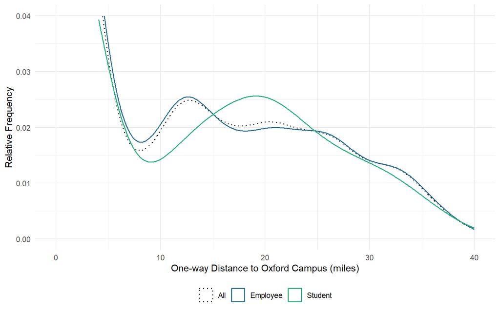

#### Table 03: Numerical Summary of Round-trip Commuter Gas-powered Vehicle Mileage

| Designation | # Responses | # in Population | Population Coverage | Mean | Standard deviation | Standard error | Min | Quantile 1 | Median | Quantile 3 | Max | Daily Total |
| --- | --- | --- | --- | --- | --- | --- | --- | --- | --- | --- | --- | --- |
| All | 2241 | 4474 | 50.09% | 23.49 | 22.38 | 0.47 | 0 | 2.96 | 18.92 | 41.27 | 87.82 | 52631.36 |
| Employee | 1935 | 3937 | 49.15% | 23.69 | 22.29 | 0.51 | 0 | 3.38 | 18.96 | 41.60 | 87.82 | 45833.28 |
| Student | 306 | 537 | 56.98% | 22.22 | 22.94 | 1.31 | 0 | 1.19 | 16.15 | 40.52 | 81.64 | 6798.07 |

#### Figure 03: Distribution of Commuters’ Round-trip Gas-powered Vehicle Mileage

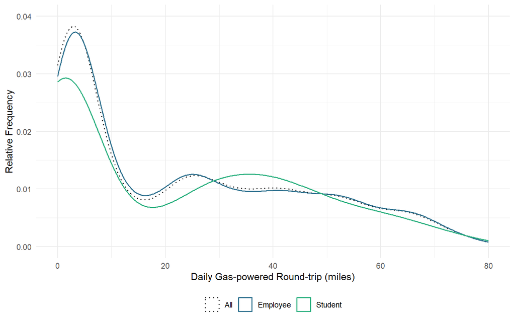

In Figure 03, a bimodal and right-skewed distribution is present for both groups of respondents. However, the reason for a high median gas-powered round trip miles for employees is made apparent by the strong dip in mileage for students around the 17.5-mile mark prior to increasing greatly around the 35-mile mark. The mean mileage is clearly influencing conclusions in the summary table in Figure 03 when considering how strongly the two modes in the density plot affect implications of the dataset. Overall, the median is a preferred choice for comparing the two groups’ averages, as noted by the bimodal patterns above.

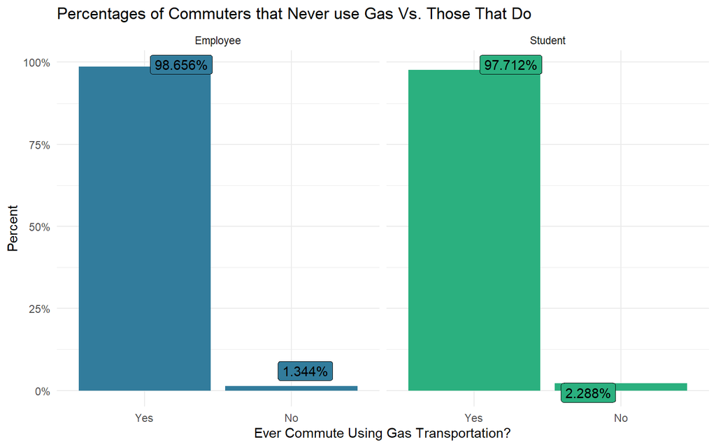

#### Figure 05: Average Percentage for each Commuting Category

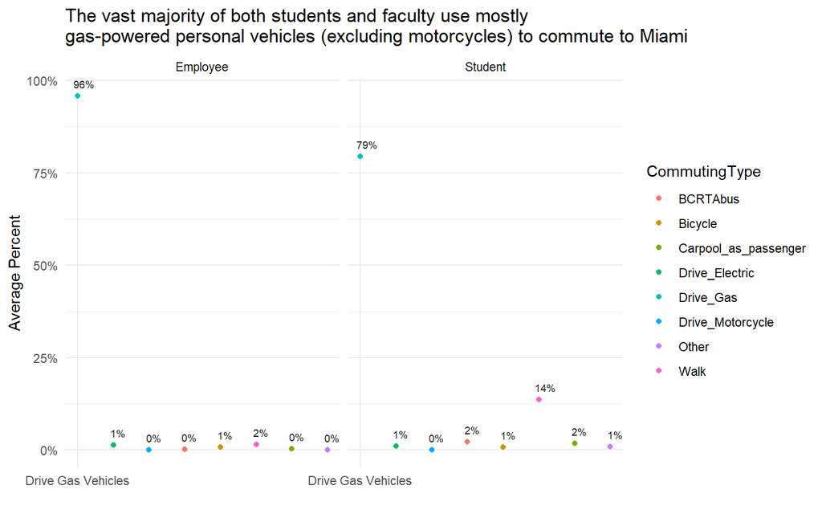

#### Table 04: Sample Point Estimates for Total Gallons and Miles Commuted for Each Commuting Type

| Commute Type | Total Miles Commuted | Total Gallons Expended |
| --- | --- | --- |
| PersonalGas | 22405752.779 | 943797.5054 |
| Electric | 201215.480 | 3365.9331 |
| Walk | 334286.604 | 0.0000 |
| Bicycle | 197618.929 | 0.0000 |
| CarpoolAsPassenger | 69179.535 | 0.0000 |
| Motorcycle | 6611.494 | 150.2612 |
| Other | 9200.263 | NA |
| BCRTABus (total from routes ran by buses all year) | 183253.000 | 18325.0000 |

#### Table 05: Total Weekly Mileage Point Estimate and Gallons of Gas Expended Commuting Point Estimates

| Carbon Mileage | Total Commuting Mileage | Gallons |
| --- | --- | --- |
| 502524 | 516085.9 | 21051.42 |

#### Table 06: Total Annual Mileage and Gallons Of Gas Expended Commuting Point Estimates

| Carbon Mileage | Total Commuting Mileage | Gallons |
| --- | --- | --- |
| 22613580 | 23223865 | 947313.7 |

#### Table 07: Commuting Student Confidence Intervals

| Category | Estimate | LowerBound | UpperBound | StandardError |
| --- | --- | --- | --- | --- |
| Weekly Commuting Mileage | 105461.859 | 102952.10 | 107971.621 | 2509.7612 |
| Weekly Carbon Commuting Mileage | 99228.487 | 96755.90 | 101701.073 | 2472.5861 |
| Weekly Gas Gallons | 4153.484 | 4048.43 | 4258.538 | 105.0541 |
| Annual Commuting Mileage | 4745783.677 | 4632844.42 | 4858722.932 | 112939.2548 |
| Annual Carbon Commuting Mileage | 4465281.916 | 4354015.54 | 4576548.292 | 111266.3761 |
| Annual Gas Gallons | 186906.769 | 182179.34 | 191634.202 | 4727.4332 |

#### Table 08: Commuting Employee Confidence Intervals

| Category | Estimate | LowerBound | UpperBound | StandardError |
| --- | --- | --- | --- | --- |
| Weekly Commuting Mileage | 927839.31 | 920436.98 | 935241.64 | 7402.3293 |
| Weekly Carbon Commuting Mileage | 907505.41 | 900170.29 | 914840.53 | 7335.1202 |
| Weekly Gas Gallons | 38009.92 | 37697.19 | 38322.65 | 312.7301 |
| Annual Commuting Mileage | 41752769.00 | 41419664.19 | 42085873.82 | 333104.8173 |
| Annual Carbon Commuting Mileage | 40837743.48 | 40507663.07 | 41167823.89 | 330080.4089 |
| Annual Gas Gallons | 1710446.53 | 1696373.67 | 1724519.38 | 14072.8525 |

#### Table 09: All Commuters Confidence Intervals

| Category | Estimate | LowerBound | UpperBound | StandardError |
| --- | --- | --- | --- | --- |
| Weekly Commuting Mileage | 1033872.84 | 1026185.03 | 1041560.65 | 7687.8088 |
| Weekly Carbon Commuting Mileage | 1003253.40 | 995557.40 | 1010949.40 | 7696.0001 |
| Weekly Gas Gallons | 42397.51 | 42074.67 | 42720.36 | 322.8439 |
| Annual Commuting Mileage | 46545836.91 | 46199885.51 | 46891788.30 | 345951.3938 |
| Annual Carbon Commuting Mileage | 45146403.07 | 44800083.06 | 45492723.07 | 346320.0052 |
| Annual Gas Gallons | 1910043.72 | 1895515.75 | 1924571.69 | 14527.9733 |

## IV. Discussion and Limitations

Separate consideration of BCRTA bus estimates represents a complication in analysis results. Because the estimates were adapted from BCRTA reports, they did not, and could not, incorporate survey data. As a result of directly provided numbers and strong assumptions on bus MPG, no estimate of uncertainty for any of the bus mileage, gallons consumed, or carbon emissions could be provided using bootstrapping or other basic statistical tools. Furthermore, conclusions made from the data provided in the BCRTA reports was largely deductive and therefore subjective. The shared Hamilton-Oxford garage reports an annual gasoline and gasoline from diesel-equivalent consumption of 156300 gallons (“Alternative Fuel Strategy,” 2023). The estimate for Oxford’s campus buses fits into this estimate as a small proportion, potentially due to the conservative estimate along with the inclusion of long connecting lines for the combined fleet gasoline report here. If a smaller or larger estimate of MPG for BCRTA gasoline consumption is used instead of 10 MPG, for example, the annual estimate can change by thousands of gallons annually. Also, the buses idle frequently, potentially increasing the true miles per gallon consumed to a MPG estimate lower than those reported. Additional research around BCRTA, especially in conjunction with university communications regarding specific bus MPG ratings, is recommended for future adaptations of this analysis.

No adjustment was applied to control for the difference between vehicle mileage on city roads compared to highway roads, which represents additional potential error introduced as a result of variation in MPG consumption for driving distances from the city of Oxford. This decision was made due to the lack of information regarding specific respondents’ vehicle make and model, absence of literature surrounding BCRTA buses’ makes and models, and the general choice to utilize the U.S. Department of Energy’s overarching “average” U.S. personal vehicle MPG estimate. Because the U.S. Department of Energy’s estimate was supplied in the context universal to personal vehicles, a limitation arises in the assumption this estimate already considered differences between city and highway MPG ratings.

As mentioned, the biggest limitation of this analysis is the lack of granular data from the survey. Since only very broad, general data is granted, a lot of assumptions must be made. For example, adjusting for Euclidean distance used subjective assumptions around which measurements should be weighted more. Alternatively, future survey data could include a true commute distance, or a rough estimate, if not a violation of the respondent’s privacy. Other approaches to this analysis could incorporate weights corresponding to housing populations in oxford using a geostatistical variogram or density map. This would require population density data for Oxford, which may or may not be readily accessible. Another caveat is the design of the survey questions, because while most seem very clear, there are other ways to interpret the questions that were potentially not accounted for in the analysis, which could skew the results either way. For example, commute percentages for varieties of vehicles that consume any amount of gasoline are all pooled in one category, preventing an accurate estimate of vehicle mileage and enforcing the necessity for an overarching “average personal MPG” number utilized here. Furthermore, the MPG for electric vehicles was also chosen subjectively using “best judgment.” A recommendation for future commuter surveys is to make sure all survey questions are clear when asked, and to potentially expand on the class of transportation being used, so that more accurate mile per gallon estimates can be used. This ensures a more thorough consideration for which transportation modes are being used and get a better estimate as to how many gallons of gas are consumed.

## V. References

Alternative Fuels Data Center: Maps and data. (n.d.). https://afdc.energy.gov/data.

Bivand R, Pebesma E, Gomez-Rubio V (2013). *Applied spatial data analysis with R, Second edition*. Springer, NY. https://asdar-book.org/.

Boscoe, F. P., Henry, K. A., & Zdeb, M. S. (2012). A Nationwide Comparison of Driving Distance Versus Straight-line Distance to Hospitals. *The Professional Geographer, 64*(2), 188–196. https://doi.org/10.1080/00330124.2011.583586.

Butler County Regional Transit Authority. (2023a). (rep.). *Alternative Fuel Strategy Final Report*. Retrieved October 22, 2024, from https://www.butlercountyrta.com/wp-content/uploads/2024/06/2023-BCRTA-Alternative-Fuel-Strategy-FINAL-Report-rev-3-31-2023.pdf.

Butler County Regional Transit Authority. (2023b). (rep.). *BCRTA Transit Plan Final Report*. Retrieved October 22, 2024, from https://www.butlercountyrta.com/wp-content/uploads/2024/06/BCRTA-Transit-Plan-Final-Report.pdf.

Butler County Regional Transit Authority. (n.d.). *Bus Routes & Information.* Butler County Regional Transit Authority. https://www.butlercountyrta.com/routes/view-all-routes/.

Chao, M.-T., & Lo, S.-H. (1985). *A Bootstrap Method for Finite Population. Sankhyā: The Indian Journal of Statistics, Series A (1961-2002), 47*(3), 399–405. http://www.jstor.org/stable/25050557>.

Cheng J, Schloerke B, Karambelkar B, Xie Y (2024). *leaflet: Create Interactive Web Maps with the JavaScript ‘Leaflet’ Library*. R package version 2.2.2, https://CRAN.R-project.org/package=leaflet.

Environmental Protection Agency. (2024, August 23). *Greenhouse Gas Emissions from a Typical Passenger Vehicle.* Environmental Protection Agency. https://www.epa.gov/greenvehicles/greenhouse-gas-emissions-typical-passenger-vehicle.

Fandom, Inc. (2022, March 16). *ElDorado National Aerotech*. SamTrans Wiki. https://samtrans.fandom.com/wiki/ElDorado_National_Aerotech.

Google. (n.d.). [Google Maps Directions for Driving From Upham Hall, Oxford, OH to Surrounding 40-mile Radius Locations]. Retrieved October 18, 2024, from https://maps.app.goo.gl/JrAhSyB9exeBrKW5A.

Huang L (2023). *leaflet.providers: Leaflet Providers*. R package version 2.0.0, https://CRAN.R-project.org/package=leaflet.providers.

LTI Bus Research and Testing Center. (2010). (rep.). *Partial STURAA Test 12 Year 500,000 Mile Bus from Gillig Model Low Floor.* Retrieved October 22, 2024, from https://www.altoonabustest.psu.edu/bus-details.aspx?BN=0914-P.

Miami University. (2024, March). Miami 2040: Miami University’s Climate Action Plan. https://miamioh.edu/about/sustainability/_documents/miami-2040-climate-action-plan-mar-2024_508.pdf.

Oak Ridge National Laboratory. (n.d.). **Greenhouse Gas Emissions From Electric and Plug-in Hybrid Vehicles.** www.fueleconomy.gov. https://www.fueleconomy.gov/feg/Find.do?action=bt2.

Odlozil, K. (2023, May 9). *Comparing Types of Buses and Their MPG.* P-Fleet. https://www.pfleet.com/blog/comparing-types-of-buses-and-their-mpg.

Pebesma E, Bivand R (2005). “Classes and methods for spatial data in R.” *R News*, *5*(2), 9-13. https://CRAN.R-project.org/doc/Rnews/.

Slowikowski K (2024). *ggrepel: Automatically Position Non-Overlapping Text Labels with ‘ggplot2’*. R package version 0.9.6, https://CRAN.R-project.org/package=ggrepel.

Statista. (2024, October 22). Car by type in the U.S. 2024. https://www.statista.com/forecasts/997118/car-by-type-in-the-us

Wickham H, Francois R, Henry L, Muller K, Vaughan D (2023). *dplyr: A Grammar of Data Manipulation*. R package version 1.1.4, https://CRAN.R-project.org/package=dplyr.

Wickham H, Averick M, Bryan J, Chang W, McGowan LD, Françoi R, Grolemun G, Haye A, Henr L, Heste J, Kuh M, Pederse TL, Mille E, Bach SM, Müll K, Oo ,J, Robins ,D, Seid ,DP, Spi ,V, Takahas ,K, Vaugh ,D, Wil ,C, W,K, Yutani ,H (2019). “Welcome to the tidyverse.” *Journal of Open Source Software*, *4*(43), 1686. doi:10.21105/joss.01686 https://doi.org/10.21105/joss.01686.

Zhu H (2024). *kableExtra: Construct Complex Table with ‘kable’ and Pipe Syntax*. R package version 1.4.0, https://CRAN.R-project.org/package=kableExtra.

## VI. Appendix

#### Appendix A. Total Days Driven in a Year for Each Commute Category

| DESIGNATION | TotalSpringFallSemDays | TotalSummerSemDays | TotalJtermSemDays | DaysGasDriven | DaysElectricDriven | DaysWalk |
| --- | --- | --- | --- | --- | --- | --- |
| Employee | 120 | 48 | 12 | 180 | 0 | 0 |
| Employee | 120 | 0 | 0 | 120 | 0 | 0 |
| Employee | 150 | 36 | 9 | 195 | 0 | 0 |
| Employee | 150 | 12 | 3 | 165 | 0 | 0 |
| Employee | 150 | 48 | 12 | 210 | 0 | 0 |
| Employee | 150 | 60 | 15 | 225 | 0 | 0 |

| DaysBicycle | DaysBCRTAbus | DaysCarPoolPass | DaysDriveMotorcycle | DaysOther | roundtrip_miles | daily_miles_one_way |
| --- | --- | --- | --- | --- | --- | --- |
| 0 | 0 | 0 | 0 | 0 | 32.444280 | 16.222140 |
| 0 | 0 | 0 | 0 | 0 | 29.849194 | 14.924597 |
| 0 | 0 | 0 | 0 | 0 | 41.841691 | 20.920846 |
| 0 | 0 | 0 | 0 | 0 | 2.897991 | 1.448995 |
| 0 | 0 | 0 | 0 | 0 | 50.791995 | 25.395998 |
| 0 | 0 | 0 | 0 | 0 | 51.970667 | 25.985333 |

#### Appendix B.1 Example of Adjusted Commute Distance, Using True Driving Distance Factor (1-Mile Radius Adjustment Applied)

| Designation | Adjustment Factor (1-mile) | Daily Miles One-Way | Daily Miles Round-Trip | Daily Miles Round-Trip (Adjusted) |
| --- | --- | --- | --- | --- |
| Employee | 1.54 | 1.45 | 2.90 | 4.47 |
| Employee | 1.54 | 0.83 | 1.66 | 2.55 |
| Employee | 1.54 | 1.38 | 2.76 | 4.25 |
| Employee | 1.54 | 1.04 | 2.07 | 3.20 |
| Employee | 1.54 | 1.12 | 2.25 | 3.47 |
| Employee | 1.54 | 0.99 | 1.98 | 3.06 |

#### Appendix B.2 True Commute Driving Distance Comparison

| Daily Miles One-Way (Euclidean Distance) | Daily Miles One-Way (Driving Distance Average) | Factor |
| --- | --- | --- |
| 1 | 1.54 | 1.54 |
| 2 | 2.84 | 1.42 |
| 3 | 4.06 | 1.35 |
| 5 | 6.88 | 1.38 |
| 10 | 12.52 | 1.25 |
| 15 | 17.73 | 1.18 |
| 20 | 25.37 | 1.27 |
| 25 | 31.18 | 1.25 |
| 35 | 46.78 | 1.34 |

#### Appendix B.3 Factors Applied to Binned Distances

| Daily Miles One-Way (Euclidean Distance) Greater Than | Daily Miles One-Way (Euclidean Distance) At Most | Factor Applied |
| --- | --- | --- |
| 0 | 0.5 | None |
| 0.5 | 1.5 | 1.54 |
| 1.5 | 2.5 | 1.42 |
| 2.5 | 4 | 1.35 |
| 4 | 7.5 | 1.38 |
| 7.5 | 12.5 | 1.25 |
| 12.5 | 17.5 | 1.18 |
| 17.5 | 22.5 | 1.27 |
| 22.5 | 30 | 1.25 |
| 30 | 40 | 1.34 |